# GAM

Master Data Science: Verónica Gómez, Carlos Grande, Pablo Olmos

2020

## Planteamiento del Problema

Intetaremos a través de las nuevas técnicas conocidase en el trimestre para intentar predecir la variable dependiente Precio de Compra. Vamos a aboradar el proceso de dos maneras: 1.-Por un lado tenemos la Variable Precio de forma continúa, ésta será nuestra variable objetivo dentro de un modelo GAM 2.-y por otro depúes de haber terminado el análisis clúster de las poblaciones de viviendas dividido en Top, Med y Low intentaremos predecir la pertenencia a cada unos de los grupos a través de un GAM, link function multiclass logistic.

Por último destacar como punto clave que la literatura recomienda usar modelos GAM en el caso de que exista un problema de Geolocalización en los datos con coordenadar X,Y como es nuestro caso.

# Secuencia del Trabado Modelo GAM1:

Lectura del Fichero  
Ridge y Lasso selección de variables GAM model Validación e interpretación de los datos.

# 1. Modelo GAM. Variable Dependiente Precio Continua.

https://pdfs.semanticscholar.org/dea4/adaaf06e6fc99179a2620b7a031188c6e532.pdf

Como pudimos comprobar en el trimestre anterior los tradicionales modelos lineales a menudo fallan cuando planteamos problemas no lineales que suele ser lo habitual en la vida real. Con esta técnica queremos identificar los efectos no lineales de nuestros dantos dentro de un modelo predictivo de regresión.

Los GAM son un buen punto intermedio entre los modelos lineales (lm) y los modelos no paramétricos (p.e. Random Forest)

Planteamos el uso del modelo GAM dentro de la Regression Lineal ya que hemos comprobado que nuestro modelo contiene efectos no lineales.

1.- Las relaciones entre los predictores individuales y la variable dependiente siguen una función Smooth (suavizada), que puede ser lienal o no. 2.- Podemos estimar estas relaciones simultáneamente y predecir g(e(Y)) simplemente sumándolas 3.- Matemáticamente, GAM como

```
      g(E(Y))= a + s1(x1) + ....+ sp(zp)

    donde Y es la variable dependiente y g(Y) link function que vincula Y con x1,x2...xp

s(x1), s(x2)...s(xp)  son las smooth non parametrics fuctions (small set of parameters)
Notar quepodemos usar en GLM
for example Logit Link g(E(y))= log ( p(Y=1)/P(Y=0))
```

Las razones por las que vamos a emplear GAM son:

1.-Interpretabilidad 2.-Fexibiliad y automatización 3.-Regularización

## 1Interpretabilidad

La interepretación de un impacto marginal de una variable NO depende del valor de otras variables en el modelo. Por tanto con un simple vistazo al output del modelo podemos hacer una interepretación de la variable en el modelo. La posibilidad de controlar el ‘smoothness’ de las funciones predictoras.

## 2Flexibility and Automation

GAM es capaz de capturar patrones no lineales. Estos patrones van desde “hockey sticks” que se producen cuando se observa un “sharp” en la respuesta a varios tipos de “mountain shaped”. En los fitting de modelos parametrics de regression estos efectos no lienales son habitualmente recogidos a través de polinomios el cual genera un modelo poco eficiente. Con el modelo GAM no tenemos estos problemas, las funciones de predcicción se derivan automaticamente durante la estimación del modelo. No necesitamos saber por adelantado qué tipo de funciones necesitaremos. Ahorro de tiempo y nos encontará patrones perdidos en los modelos paramétricos.

## 3regularización

Nos permite controlar el “smoothness” de la funciones predictoras para eviar el Overfiting. Controlando “the wiggliness” evitar el sesgo. Las funciones de penalización del GAM tienen conexiones con la regresión Bayessiana y la L2.

Smoothers

```
Snoothers son las clave del GAM, tenemos tres clases de Smoothers:

1.-Local Regression (loess)
2.-Smoothing Splines
3.-Regression Splines ( B-splines, P-splines, thin plate splines)
```

RS, computacionalmente barato, es que emplearemos más habitualmente. La principal ventaja es que puede ser expresada como una combinación lienal de un conjunto finito de funciones básicas las cuales No dependen de la variable Y. S(x) => Bp,1(x)…Bp,k(x) funciones básicas donde B es la matriz dónde se albergan y B=[B1:B2:…..:Bp] son los coeficinetes. El número de funciones básicas depende de el número de “inner knots”(m) (TODO), p numero de parámetros.

Número de funciones básicas K = p + 1 + m

# Lectura Datos

Definimos una semilla aleatoria y realizamos una partición en Train 80% y Test 20%.

```r
setwd("C:/Users/Pablo/Desktop/Machine_Learning_I/Z_PRACTICA_MACHINE_LEARNING/machineLearning1Process")
df_cluster <- read.csv ("cluster.csv")

#descriptivo en cada Clúster
set.seed(767)
df_cluster %>%
        group_by(hclust) %>%
        summarise(num_casas=n(), precio_medio= mean(price), room=mean(bedrooms),baths=mean(bathrooms) ,
                  tamanyo=mean(sqft_living), anyo=floor(mean(yr_built)) ,grade=mean(grade), condicion=mean(condition),        visitas=mean(view))
```

```
## # A tibble: 9 x 10
##   hclust num_casas precio_medio  room baths tamanyo  anyo grade condicion
##    <int>     <int>        <dbl> <dbl> <dbl>   <dbl> <dbl> <dbl>     <dbl>
## 1      1      4630      483131.  3.01  1.52   1553.  1936  6.90      3.66
## 2      2      1032      869438.  3.44  2.34   2420.  1942  7.86      3.27
## 3      3      2859      581478.  3.49  2.02   2042.  1970  7.57      3.61
## 4      4      1614      619128.  3.63  2.61   2615.  1998  8.44      3.12
## 5      5      2230      381906.  3.64  2.52   2339.  1997  7.89      3.14
## 6      6      1790      540015.  3.50  2.00   2083.  1957  7.48      3.40
## 7      7      1962      568348.  3.14  2.55   1932.  2003  8.09      3.04
## 8      8      2370      864266.  3.81  2.83   3107.  1994  9.09      3.19
## 9      9      3110      286567.  3.19  1.72   1633.  1968  6.97      3.66
## # ... with 1 more variable: visitas <dbl>
```

```r
df_cluster$hclust=as.numeric(df_cluster$hclust)
df_cluster$Cluster_final[df_cluster$hclust==2 | df_cluster$hclust==8] <- "top"
df_cluster$Cluster_final[df_cluster$hclust==1 | df_cluster$hclust==5 | df_cluster$hclust==9] <- "low"
df_cluster$Cluster_final[df_cluster$hclust==3 | df_cluster$hclust==4 | df_cluster$hclust==6 | df_cluster$hclust==7  ] <- "med"



df_cluster %>%
        group_by(Cluster_final) %>%
        summarise(num_casas=n(), precio_medio= mean(price), room=mean(bedrooms),baths=mean(bathrooms) ,
                  tamanyo=mean(sqft_living), anyo=floor(mean(yr_built)) ,grade=mean(grade),condicion=mean(condition),visitas=mean(view))
```

```
## # A tibble: 3 x 10
##   Cluster_final num_casas precio_medio  room baths tamanyo  anyo grade
##   <fct>             <int>        <dbl> <dbl> <dbl>   <dbl> <dbl> <dbl>
## 1 low                9970      399175.  3.21  1.81   1754.  1960  7.14
## 2 med                8225      576711.  3.44  2.26   2137.  1980  7.84
## 3 top                3402      865835.  3.70  2.68   2899.  1978  8.72
## # ... with 2 more variables: condicion <dbl>, visitas <dbl>
```

```r
set.seed(737)
inTraining <- createDataPartition(df_cluster$id, p = .8, list = FALSE)
train    <- df_cluster[inTraining,]
control  <- df_cluster[-inTraining,]
```

# Ridge regression

Intenta minimizar el RSS, ridge regression incorpora un término llamado shrinkage penalty que fuerza a que los coeficientes de los predictores tiendan a cero controlada por el parámetro λ. Cuando λ=0 la penalización es nula y los resultados son equivalentes a los obtenidos por mínimos cuadrados, cuando λ=∞ todos los coeficientes son cero. La principal ventaja es la reducción de Varianza. Si todos los predictores incluidos tienen coeficientes diferentes a cero (todos contribuyen al modelo) y aproximadamente de la misma magnitud, ridge regression tiende a funcionar mejor.

Para realizar ridge regression se va a emplear la función glmnet() del paquete glmnet.

```r
#matriz con las valores de los predictores para cada observación y un vector y=target variable respuesta
x <- model.matrix(price~  (bedrooms+ bathrooms+floors+sqft_living+grade+condition+view+waterfront+                           sqft_lot+sqft_above+sqft_basement+yr_built+yr_renovated+yr_renovated+
                            sqft_living15+sqft_lot15), data = train)[, -1]
head(x)
```

```
##   bedrooms bathrooms floors sqft_living grade condition view waterfront
## 1        3      1.00      1        1180     7         3    0          0
## 2        3      2.25      2        2570     7         3    0          0
## 3        2      1.00      1         770     6         3    0          0
## 4        4      3.00      1        1960     7         5    0          0
## 5        3      2.00      1        1680     8         3    0          0
## 6        4      4.50      1        5420    11         3    0          0
##   sqft_lot sqft_above sqft_basement yr_built yr_renovated sqft_living15
## 1     5650       1180             0     1955            0          1340
## 2     7242       2170           400     1951         1991          1690
## 3    10000        770             0     1933            0          2720
## 4     5000       1050           910     1965            0          1360
## 5     8080       1680             0     1987            0          1800
## 6   101930       3890          1530     2001            0          4760
##   sqft_lot15
## 1       5650
## 2       7639
## 3       8062
## 4       5000
## 5       7503
## 6     101930
```

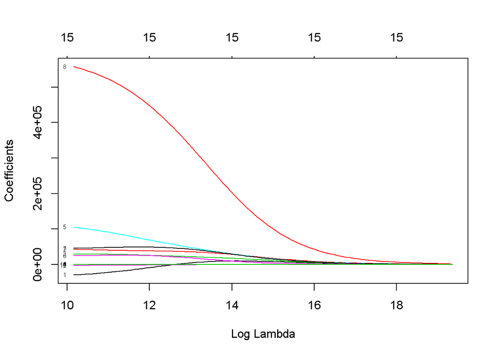

```r
y <- train$price


# Para obtener un ajuste mediante ridge regression se indica argumento alpha=0.
modelos_ridge <- glmnet(x = x, y = y, alpha = 0)
plot(modelos_ridge, xvar = "lambda", label = TRUE)
```

Al aumentar el tamaño de los Lambda dismunuyen los coeficientes. Con el fin de identificar el valor de λ que da lugar al mejor modelo, se puede recurrir a Cross-Validation. La función cv.glmnet() calcula el cv-test-error, utilizando por defecto k=10.

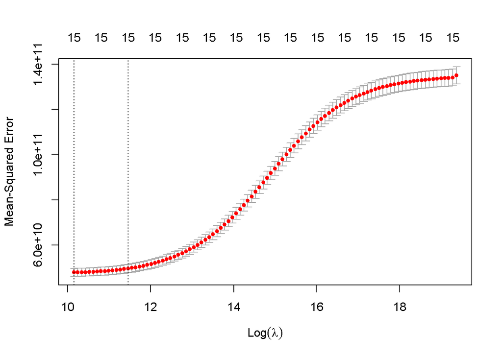

```r
set.seed(737)
cv_error_ridge <- cv.glmnet(x = x, y = y, alpha = 0, nfolds = 15,
                            type.measure = "mse")
plot(cv_error_ridge)
```

Podemos observar cómo varía el error cuadrático medio, en función del valor de regularización. Gráficamente se comprueba que el error no aumenta hasta que las variables con coeficiente mayor que cero es menor que -2, pero el menor error cuadrático medio se da para 15 variables regresoras y se mantiene constante. Es una de las grandes diferencias con Lasso.

```r
# Valor lambda con el que se consigue el mínimo test-error
cv_error_ridge$lambda.min
```

```
## [1] 25640.36
```

```r
# Valor lambda óptimo: mayor valor de lambda con el que el test-error no se
# aleja más de 1 sd del mínimo test-error posible.
cv_error_ridge$lambda.1se
```

```
## [1] 94314.97
```

```r
# Se muestra el valor de los coeficientes para el valor de lambda óptimo

modelo_final_ridge <- glmnet(x = x, y = y, alpha = 0, lambda = cv_error_ridge$lambda.1se)
coef(modelo_final_ridge)
```

```
## 16 x 1 sparse Matrix of class "dgCMatrix"
##                          s0
## (Intercept)    3.728555e+06
## bedrooms      -1.682482e+04
## bathrooms      3.928115e+04
## floors         2.763549e+04
## sqft_living    7.238227e+01
## grade          8.168695e+04
## condition      2.585563e+04
## view           4.862647e+04
## waterfront     4.939975e+05
## sqft_lot      -1.037040e-02
## sqft_above     6.644473e+01
## sqft_basement  7.801452e+01
## yr_built      -2.219504e+03
## yr_renovated   2.883636e+01
## sqft_living15  5.074075e+01
## sqft_lot15    -3.848717e-01
```

# Lasso

El método lasso, al igual que ridge regression, fuerza a que las estimaciones de los coeficientes de los predictores tiendan a cero. La diferencia es que lasso sí es capaz de fijar algunos de ellos exactamente a cero, lo que permite además de reducir la varianza, realizar selección de predictores. ∑i=1n(yi−β0−∑j=1pβjxij)2+λ∑j=1p|βj|=RSS+λ∑j=1p|βj|

Cuando solo un pequeño número de predictores de entre todos los incluidos tienen coeficientes sustanciales y el resto tienen valores muy pequeños o iguales a cero, lasso genera mejores modelos.

Selección del tunning parameter λ

```
Determinar el grado de penalización, seleccionamos un rango de valores de λ y se estima el cross-validation error resultante para cada uno, finalmente se selecciona el valor de λ para el que el error es menor y se ajusta de nuevo el modelo, esta vez empleando todas las observaciones.
```

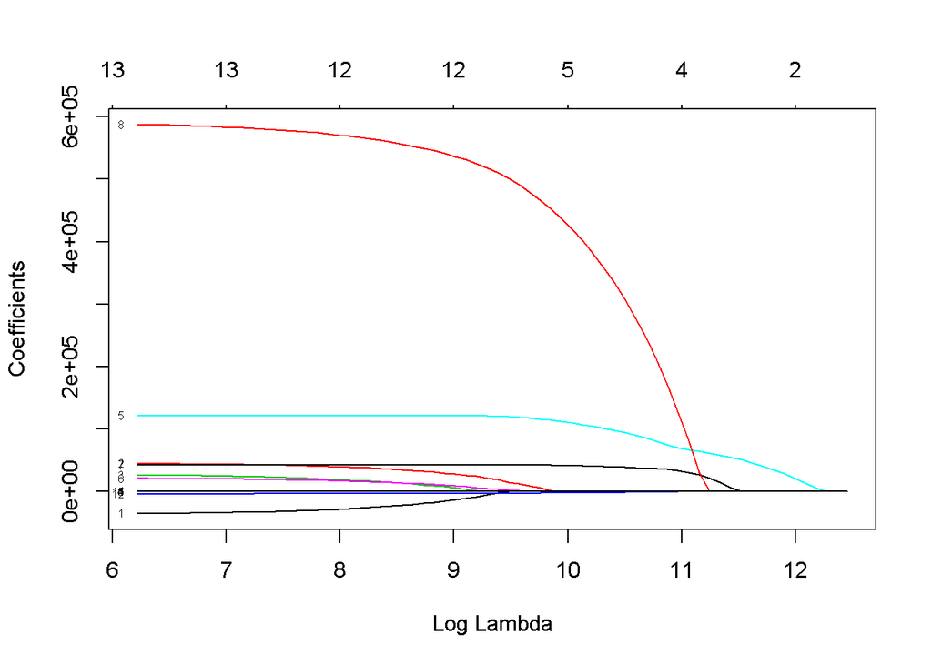

```r
modelos_lasso <- glmnet(x = x, y = y, alpha = 1)
plot(modelos_lasso, xvar = "lambda", label = TRUE)
```

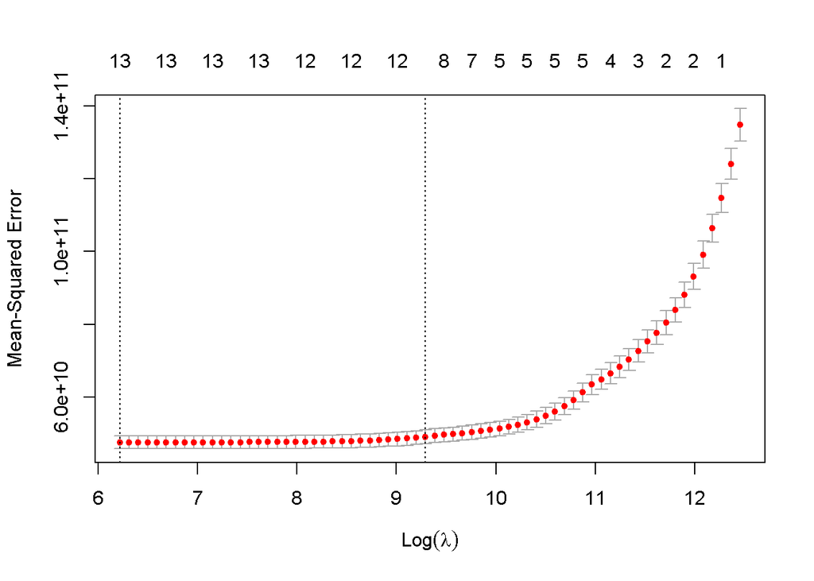

```r
set.seed(737)
cv_error_lasso <- cv.glmnet(x = x, y = y, alpha = 1, nfolds = 10)
plot(cv_error_lasso)
```

```r
cv_error_lasso$lambda.min
```

```
## [1] 503.3306
```

```r
cv_error_lasso$lambda.1se
```

```
## [1] 10843.93
```

```r
# Se reajusta el modelo con todas las observaciones empleando el valor de
# lambda óptimo

modelo_final_lasso <- glmnet(x = x, y = y, alpha = 1, lambda = cv_error_lasso$lambda.1se)
coef(modelo_final_lasso)
```

```
## 16 x 1 sparse Matrix of class "dgCMatrix"
##                          s0
## (Intercept)    4.698544e+06
## bedrooms      -5.346293e+03
## bathrooms      2.198037e+04
## floors         .
## sqft_living    1.493514e+02
## grade          1.208508e+05
## condition      4.947837e+03
## view           4.290962e+04
## waterfront     5.184063e+05
## sqft_lot       .
## sqft_above     .
## sqft_basement  .
## yr_built      -2.773078e+03
## yr_renovated   .
## sqft_living15  6.691460e+00
## sqft_lot15    -6.208087e-02
```

```r
first_ELEVEN <- max(which(cv_error_lasso$nzero == 11))
my_lam <- cv_error_lasso$lambda[first_ELEVEN]
out_ELEVEN <- glmnet(x,y,alpha=1,lambda = my_lam)
lasso_coef_ELEVEN <- predict(out_ELEVEN,type="coefficients")
lasso_coef_ELEVEN
```

```
## 16 x 1 sparse Matrix of class "dgCMatrix"
##                          s0
## (Intercept)    4.966618e+06
## bedrooms      -1.071363e+04
## bathrooms      2.639383e+04
## floors         4.208684e+03
## sqft_living    1.513446e+02
## grade          1.209347e+05
## condition      7.641584e+03
## view           4.289047e+04
## waterfront     5.310067e+05
## sqft_lot       .
## sqft_above     .
## sqft_basement  .
## yr_built      -2.916815e+03
## yr_renovated   .
## sqft_living15  9.106338e+00
## sqft_lot15    -1.500867e-01
```

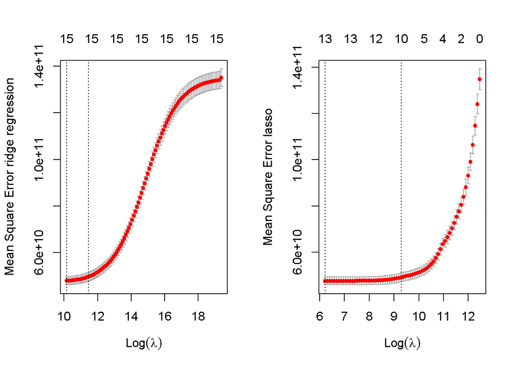

```r
par(mfrow = c(1,2))
plot(cv_error_ridge,ylab = "Mean Square Error ridge regression" )
abline(h = 120000)
plot(cv_error_lasso,ylab = "Mean Square Error lasso")
abline(h = 120000)
```

```r
par(mfrow = c(1,1))
```

# GAM

## How Regression Splines Work

Cubic B-spline requiere 2(q+1)+m . Los inners Knots son lo puntos de estimación necesarios para calcular una smooth función, es decir como una guía de la función smooth¿?, y de qué depende¿? de la variable x¿? The boundary knots son arbitrarios ( esto es aleatorio) y se sitúan en los extremos de los inner knots.¿? Entiendo que son los nudo por donde pasa la Spline a mayor número Overfitting a menor mala estimación.

RSS= Suma (yi-g(xi))2 —> Overfit data , makes RSS small but that also smooth How g is smooth, function

Sum (yi-g(xi))2 +lambda *integral ( g’’(t)2 dt) donde Lambda is not-negative

## Configuración espacial continua

```r
## gam regression
## listado de variables seleccionadas a partior del Lasso

model_gam <- gam (price~ s(lat,long) +s(sqft_living)  +s(sqft_living15) + s(sqft_lot15) + s(bedrooms)  + s(bathrooms)  + s(grade)   + waterfront + s(condition,k=3) + s(view,k=3) + s(yr_built) , data=train, method="REML")


summary(model_gam)
```

```
##
## Family: gaussian
## Link function: identity
##
## Formula:
## price ~ s(lat, long) + s(sqft_living) + s(sqft_living15) + s(sqft_lot15) +
##     s(bedrooms) + s(bathrooms) + s(grade) + waterfront + s(condition,
##     k = 3) + s(view, k = 3) + s(yr_built)
##
## Parametric coefficients:
##             Estimate Std. Error t value Pr(>|t|)
## (Intercept)   536064       1128  475.06   <2e-16 ***
## waterfront    571568      15852   36.06   <2e-16 ***
## ---
## Signif. codes:  0 '***' 0.001 '**' 0.01 '*' 0.05 '.' 0.1 ' ' 1
##
## Approximate significance of smooth terms:
##                     edf Ref.df       F  p-value
## s(lat,long)      28.879 28.999 455.659  < 2e-16 ***
## s(sqft_living)    8.979  9.000 401.887  < 2e-16 ***
## s(sqft_living15)  7.274  8.209  21.698  < 2e-16 ***
## s(sqft_lot15)     8.785  8.986  24.104  < 2e-16 ***
## s(bedrooms)       4.858  5.728   9.813 2.97e-10 ***
## s(bathrooms)      8.938  8.997  38.044  < 2e-16 ***
## s(grade)          8.534  8.905 206.532  < 2e-16 ***
## s(condition)      1.062  1.121 171.534  < 2e-16 ***
## s(view)           1.980  2.000 316.530  < 2e-16 ***
## s(yr_built)       7.702  8.564  23.597  < 2e-16 ***
## ---
## Signif. codes:  0 '***' 0.001 '**' 0.01 '*' 0.05 '.' 0.1 ' ' 1
##
## R-sq.(adj) =  0.839   Deviance explained =   84%
## -REML = 2.3027e+05  Scale est. = 2.1742e+10  n = 17280
```

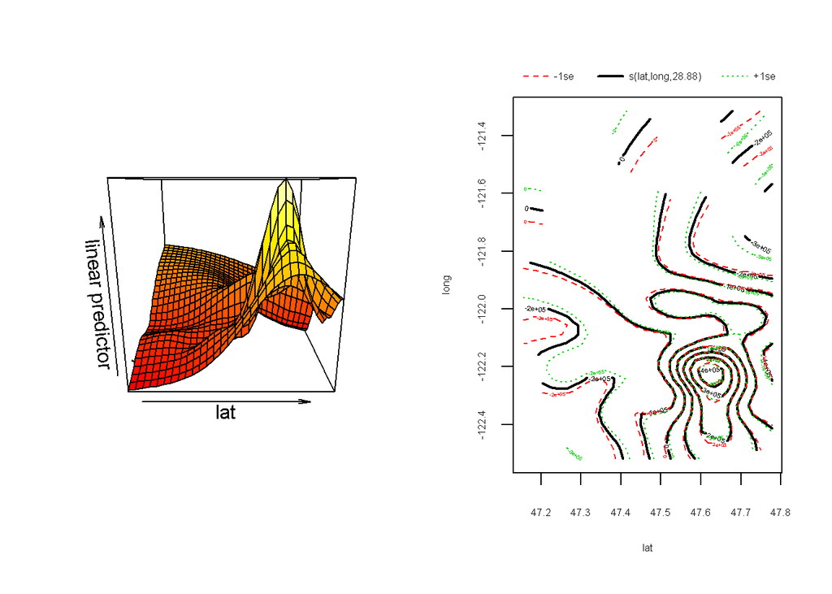

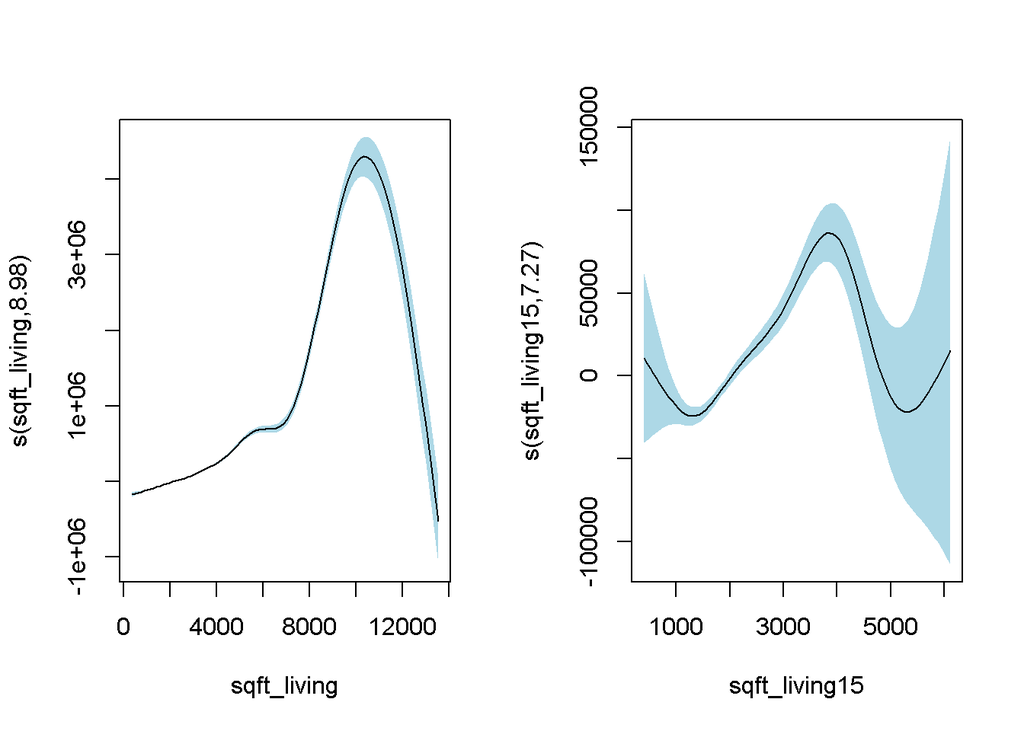

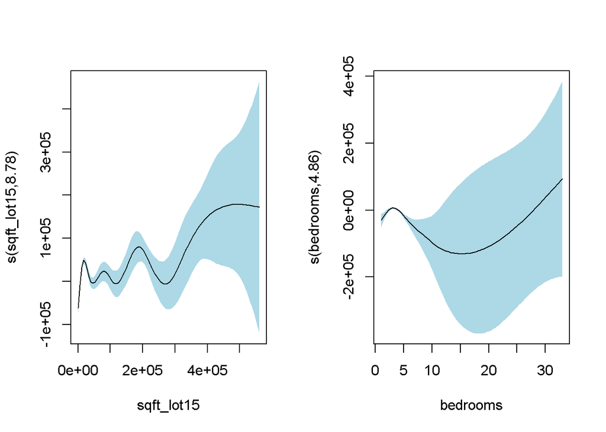

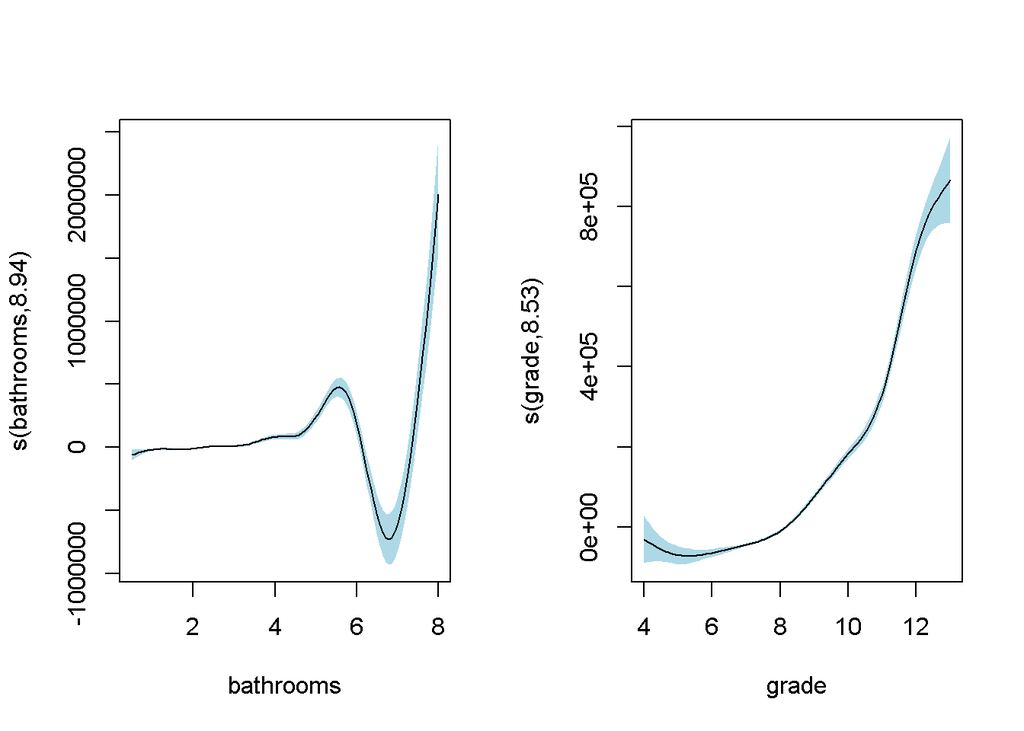

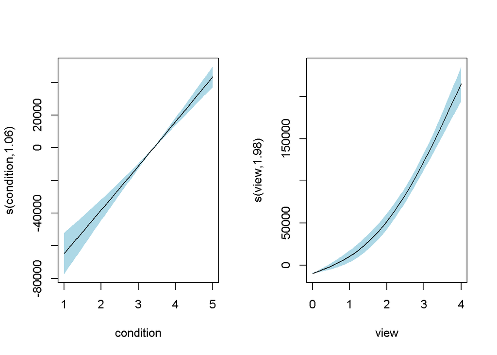

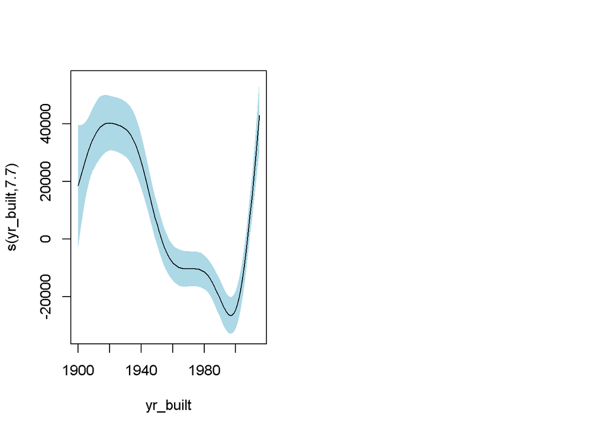

```r
layout(matrix(1:2, ncol = 2))
vis.gam (x=model_gam,view=c("lat","long"),plot.type="persp")
plot(model_gam, scale = 0,shade = TRUE, shade.col = "lightblue")
```

### Añadimos la constante para la interpretabilidad de los Smooths

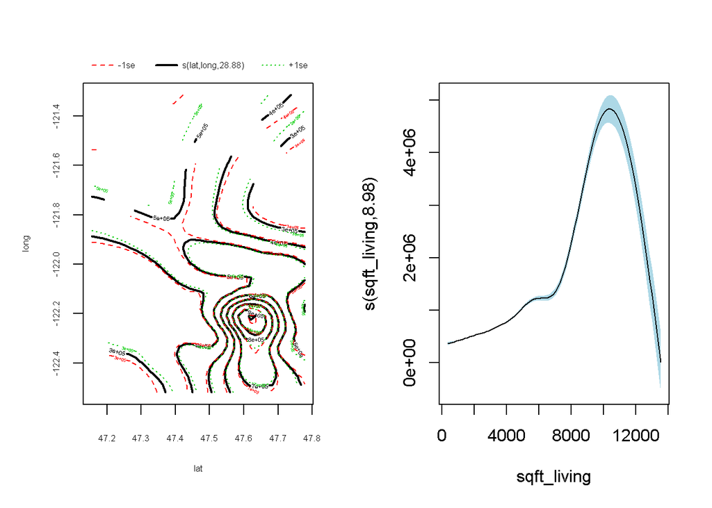

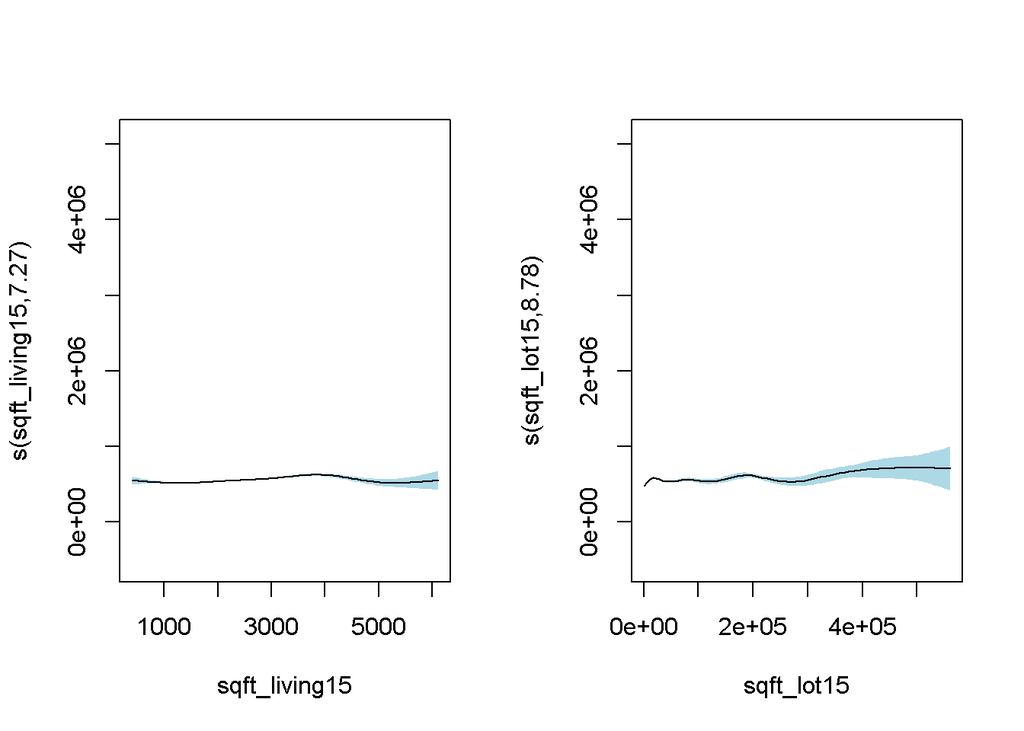

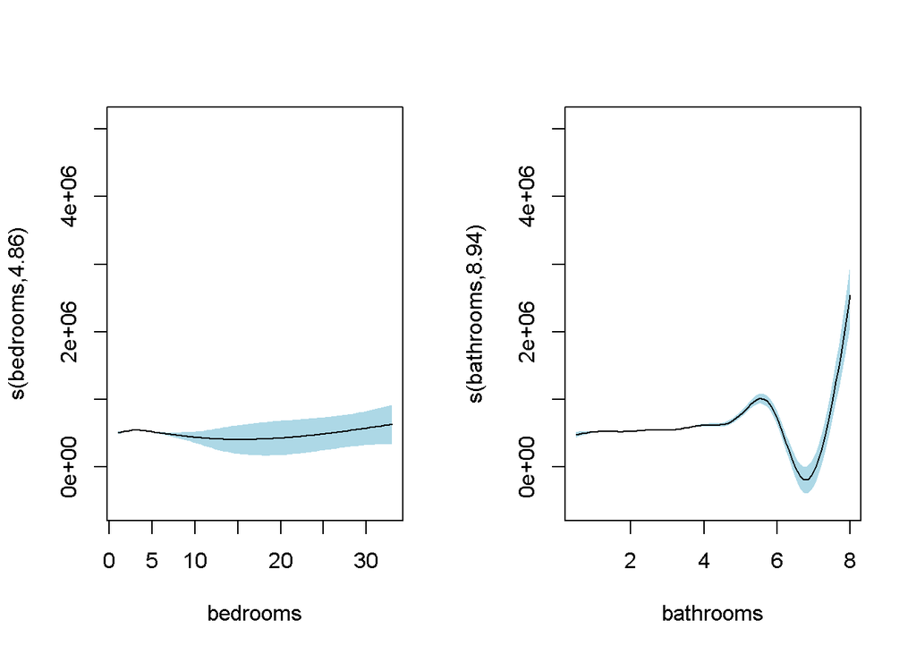

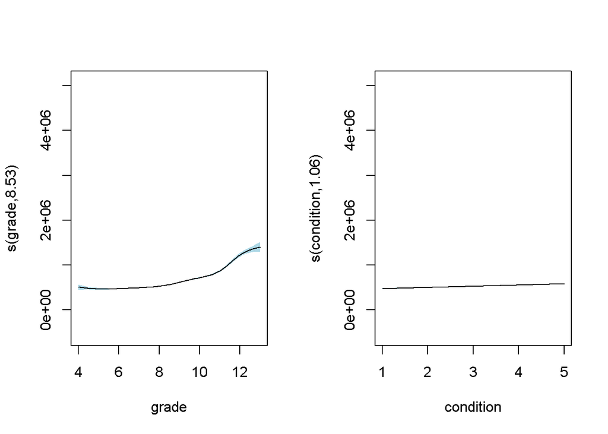

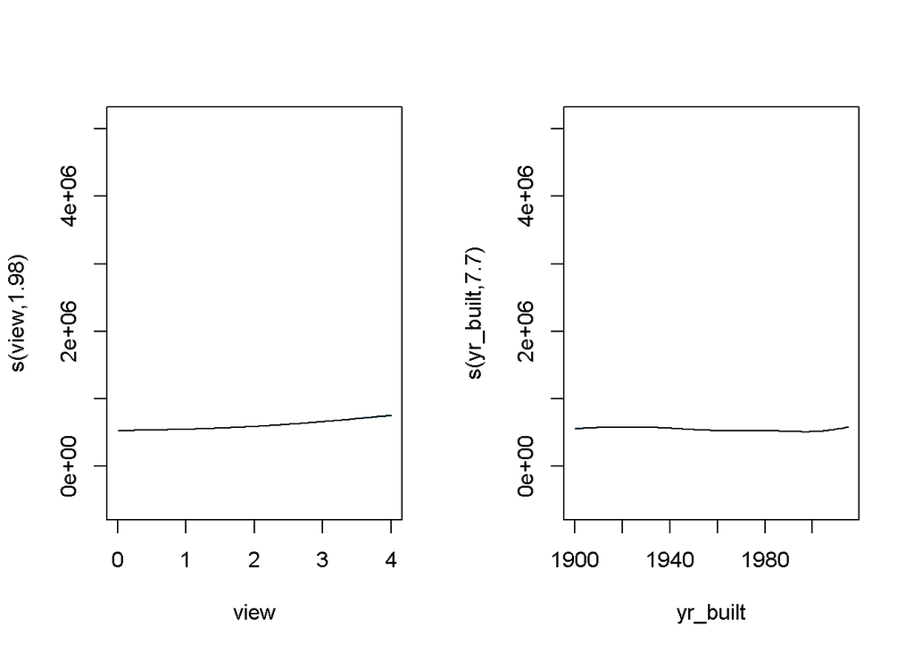

```r
layout(matrix(1:2, ncol = 2))
plot(model_gam,shade = TRUE, shade.col = "lightblue", shift=coef(model_gam)[1])
```

Viendo los gráficos podemos afirmar que La variable Condition es Lineal y View es posible que también, ambas variables son siginificativas segúne el p-valor y el valor de " edf" en condition es muy cercano a 1 por lo que podemos afirmar que ### se ajusta a una relación lineal. La variable view es muy cercana a 2 y es significativa. No es lineal

### Relanzamos el modelo GAM incluyendo la variable condition sin Smooth, Versión 2

```r
## gam regression
## listado de variables . Condition como Lineal


model_gam2 <- gam (price~ s(lat,long) +s(sqft_living)  +s(sqft_living15) + s(sqft_lot15) + s(bedrooms)  + s(bathrooms)  + s(grade)   + waterfront + condition + s(view,k=3) + s(yr_built) , data=train, method="REML")


summary(model_gam2)
```

```
##
## Family: gaussian
## Link function: identity
##
## Formula:
## price ~ s(lat, long) + s(sqft_living) + s(sqft_living15) + s(sqft_lot15) +
##     s(bedrooms) + s(bathrooms) + s(grade) + waterfront + condition +
##     s(view, k = 3) + s(yr_built)
##
## Parametric coefficients:
##             Estimate Std. Error t value Pr(>|t|)
## (Intercept)   443171       6810   65.08   <2e-16 ***
## waterfront    571576      15852   36.06   <2e-16 ***
## condition      27247       1970   13.83   <2e-16 ***
## ---
## Signif. codes:  0 '***' 0.001 '**' 0.01 '*' 0.05 '.' 0.1 ' ' 1
##
## Approximate significance of smooth terms:
##                     edf Ref.df       F  p-value
## s(lat,long)      28.879 28.999 455.657  < 2e-16 ***
## s(sqft_living)    8.979  9.000 401.905  < 2e-16 ***
## s(sqft_living15)  7.274  8.210  21.698  < 2e-16 ***
## s(sqft_lot15)     8.785  8.986  24.105  < 2e-16 ***
## s(bedrooms)       4.858  5.728   9.813 2.97e-10 ***
## s(bathrooms)      8.940  8.997  38.068  < 2e-16 ***
## s(grade)          8.534  8.905 206.513  < 2e-16 ***
## s(view)           1.980  2.000 316.512  < 2e-16 ***
## s(yr_built)       7.701  8.564  23.610  < 2e-16 ***
## ---
## Signif. codes:  0 '***' 0.001 '**' 0.01 '*' 0.05 '.' 0.1 ' ' 1
##
## R-sq.(adj) =  0.839   Deviance explained =   84%
## -REML = 2.3027e+05  Scale est. = 2.1742e+10  n = 17280
```

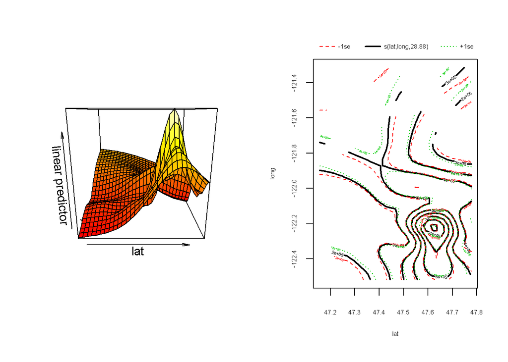

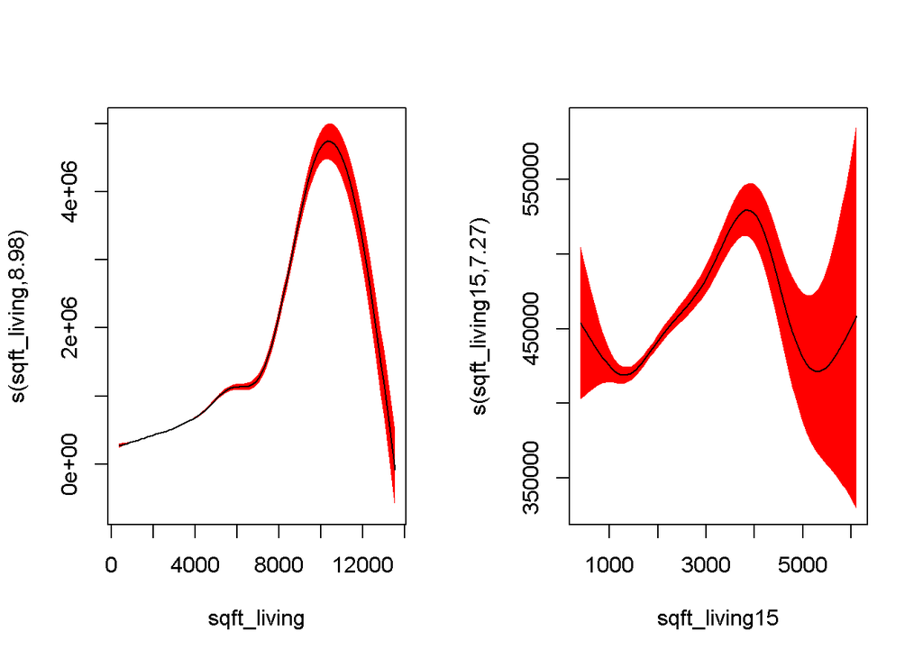

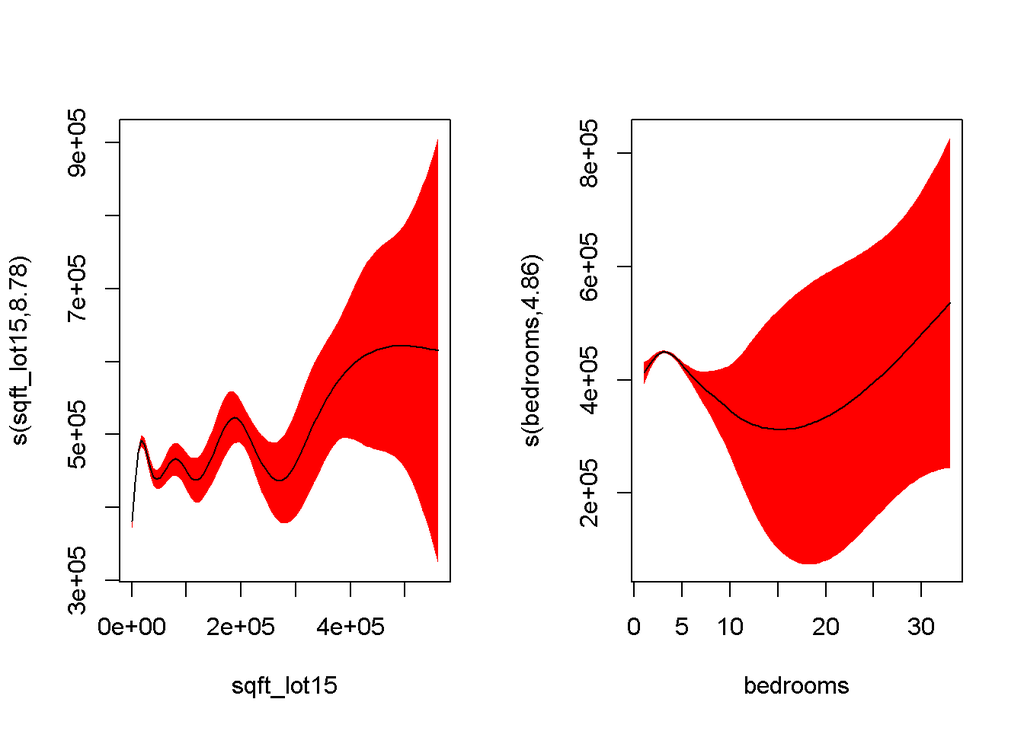

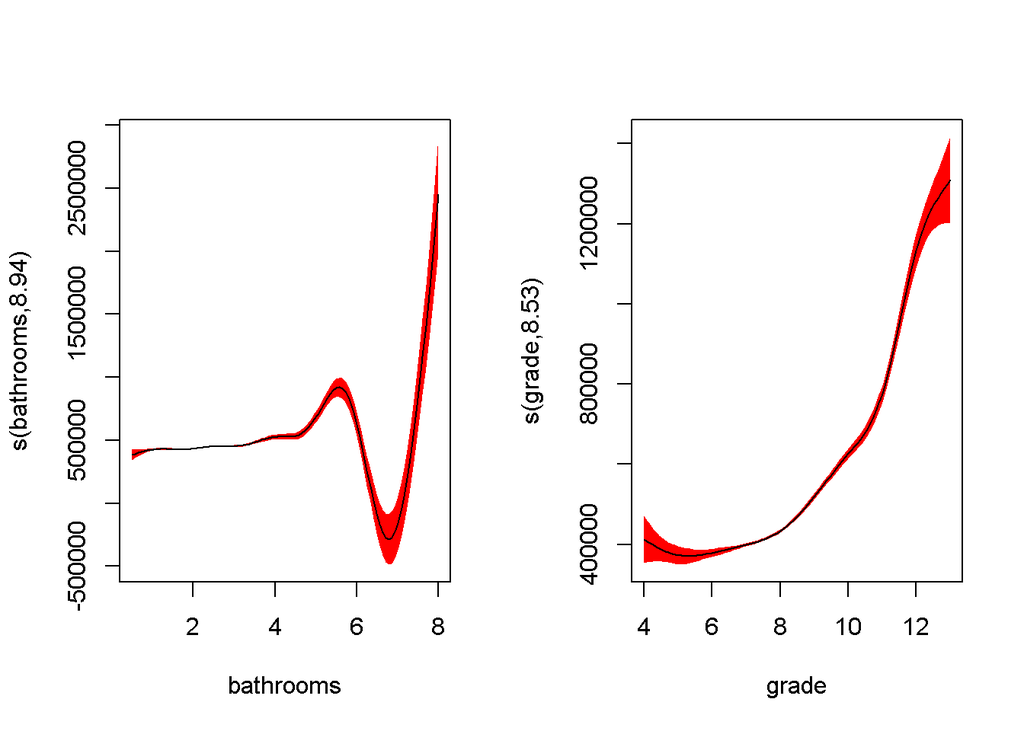

[figure not shown]

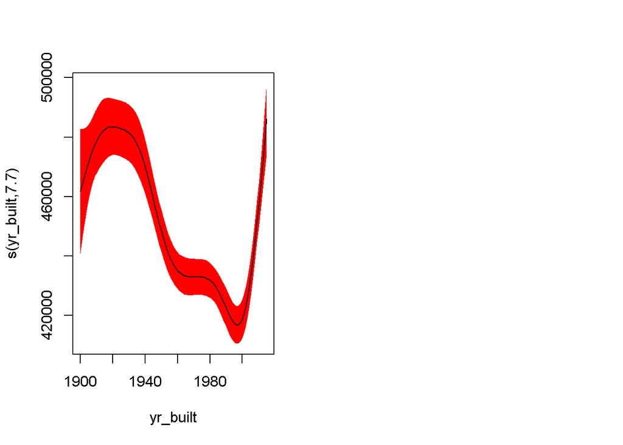

```r
layout(matrix(1:2, ncol = 2))
vis.gam (x=model_gam2,view=c("lat","long"),plot.type="persp")
plot(model_gam, scale = 0,shade = TRUE, shade.col = "red" , shift=coef(model_gam2)[1])
```

## checking concurvity

La concurrencia ocurre cuando algún término suave en un modelo puede ser aproximado por uno o más de los otros términos suaves en el modelo. Este es a menudo el caso cuando se incluye una suavidad de espacio en un modelo, junto con suavidades de otros covariables que también varían más o menos suavemente en el espacio. Del mismo modo tiende ser un problema en modelos que incluyen un tiempo suave, junto con problemas de otro tiempo variando covariables.

Es esencialmente la forma no lineal de colinealidad, la library mgcv proporciona una medida de concurrencia y establece en la documentación si tales medidas están por encima de> 1.0 es preocupante. La literatura nos dice que se puede esperar concurvity con datos espaciales como es nuestro caso.

La concurrencia puede verse como una generalización de la co-linealidad y sus causas.

índices Relacionados Concurvity, todos entre [0,1]: 1.-Worst 2.-Observed 3.-Estimate

```r
# Check pairwise concurvity
k<-concurvity(model_gam2,full=FALSE)

#options(scipen=999)
k$worst
```

```
##                          para  s(lat,long) s(sqft_living) s(sqft_living15)
## para             1.000000e+00 3.175531e-28   1.435805e-23     4.925525e-22
## s(lat,long)      3.054943e-28 1.000000e+00   1.758427e-01     2.904355e-01
## s(sqft_living)   1.435139e-23 1.758427e-01   1.000000e+00     5.923947e-01
## s(sqft_living15) 4.924405e-22 2.904355e-01   5.923947e-01     1.000000e+00
## s(sqft_lot15)    2.394452e-26 4.101550e-01   1.189589e-01     1.701609e-01
## s(bedrooms)      2.387951e-21 1.022496e-01   4.570604e-01     2.046418e-01
## s(bathrooms)     2.357955e-19 1.518034e-01   8.319016e-01     3.393532e-01
## s(grade)         5.939974e-25 2.176118e-01   6.158477e-01     5.507071e-01
## s(view)          2.083656e-29 7.463490e-02   9.097368e-02     8.511267e-02
## s(yr_built)      5.078318e-22 4.122301e-01   1.674084e-01     1.433316e-01
##                  s(sqft_lot15)  s(bedrooms) s(bathrooms)     s(grade)
## para              2.575016e-26 2.387801e-21 2.357609e-19 5.608137e-25
## s(lat,long)       4.101550e-01 1.022496e-01 1.518034e-01 2.176118e-01
## s(sqft_living)    1.189589e-01 4.570604e-01 8.319016e-01 6.158477e-01
## s(sqft_living15)  1.701609e-01 2.046418e-01 3.393532e-01 5.507071e-01
## s(sqft_lot15)     1.000000e+00 5.728509e-02 2.291764e-02 9.062447e-02
## s(bedrooms)       5.728509e-02 1.000000e+00 2.989274e-01 1.895976e-01
## s(bathrooms)      2.291764e-02 2.989274e-01 1.000000e+00 4.600646e-01
## s(grade)          9.062447e-02 1.895976e-01 4.600646e-01 1.000000e+00
## s(view)           2.563587e-02 1.049646e-02 4.818234e-02 7.685550e-02
## s(yr_built)       3.017129e-01 1.216072e-01 3.958503e-01 2.788156e-01
##                       s(view)  s(yr_built)
## para             2.125701e-29 5.077841e-22
## s(lat,long)      7.463490e-02 4.122301e-01
## s(sqft_living)   9.097368e-02 1.674084e-01
## s(sqft_living15) 8.511267e-02 1.433316e-01
## s(sqft_lot15)    2.563587e-02 3.017129e-01
## s(bedrooms)      1.049646e-02 1.216072e-01
## s(bathrooms)     4.818234e-02 3.958503e-01
## s(grade)         7.685550e-02 2.788156e-01
## s(view)          1.000000e+00 6.099049e-03
## s(yr_built)      6.099049e-03 1.000000e+00
```

### Relanzamos el modelo GAM AFTER CONCURVITY Versión 3

### Excluímos del Modelo la variable bathrooms por alta Concurvity 0.8319

```r
# eliminamos la variable bathrooms
#   s(sqft_living)*s(bathrooms)  0.8319

model_gam3 <- gam (price~ s(lat,long) +s(sqft_living)  +s(sqft_living15) + s(sqft_lot15) + s(bedrooms)  + s(grade)   + waterfront + condition + s(view,k=3) + s(yr_built) , data=train, method="REML")


summary(model_gam3)
```

```
##
## Family: gaussian
## Link function: identity
##
## Formula:
## price ~ s(lat, long) + s(sqft_living) + s(sqft_living15) + s(sqft_lot15) +
##     s(bedrooms) + s(grade) + waterfront + condition + s(view,
##     k = 3) + s(yr_built)
##
## Parametric coefficients:
##             Estimate Std. Error t value Pr(>|t|)
## (Intercept)   440971       6828   64.58   <2e-16 ***
## waterfront    574956      15943   36.06   <2e-16 ***
## condition      27884       1974   14.12   <2e-16 ***
## ---
## Signif. codes:  0 '***' 0.001 '**' 0.01 '*' 0.05 '.' 0.1 ' ' 1
##
## Approximate significance of smooth terms:
##                     edf Ref.df       F  p-value
## s(lat,long)      28.880 28.999 460.563  < 2e-16 ***
## s(sqft_living)    8.981  9.000 590.324  < 2e-16 ***
## s(sqft_living15)  7.113  8.089  19.651  < 2e-16 ***
## s(sqft_lot15)     8.776  8.985  22.899  < 2e-16 ***
## s(bedrooms)       4.825  5.694   6.527 1.51e-06 ***
## s(grade)          8.409  8.855 222.849  < 2e-16 ***
## s(view)           1.979  2.000 325.651  < 2e-16 ***
## s(yr_built)       7.609  8.506  21.987  < 2e-16 ***
## ---
## Signif. codes:  0 '***' 0.001 '**' 0.01 '*' 0.05 '.' 0.1 ' ' 1
##
## R-sq.(adj) =  0.836   Deviance explained = 83.7%
## -REML = 2.3041e+05  Scale est. = 2.2173e+10  n = 17280
```

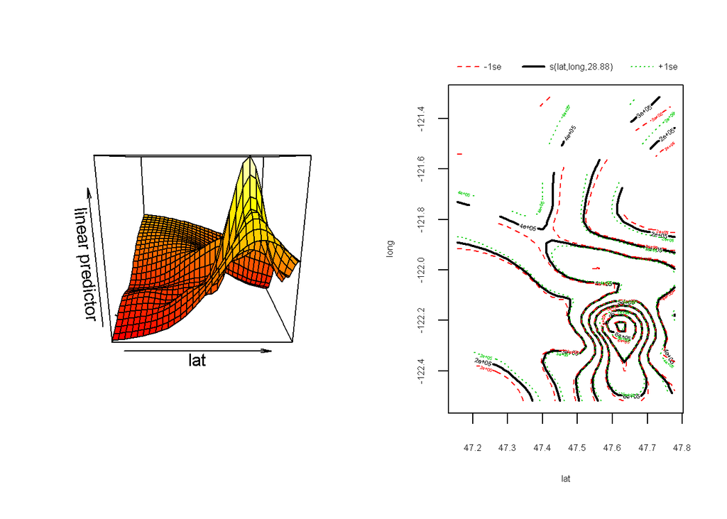

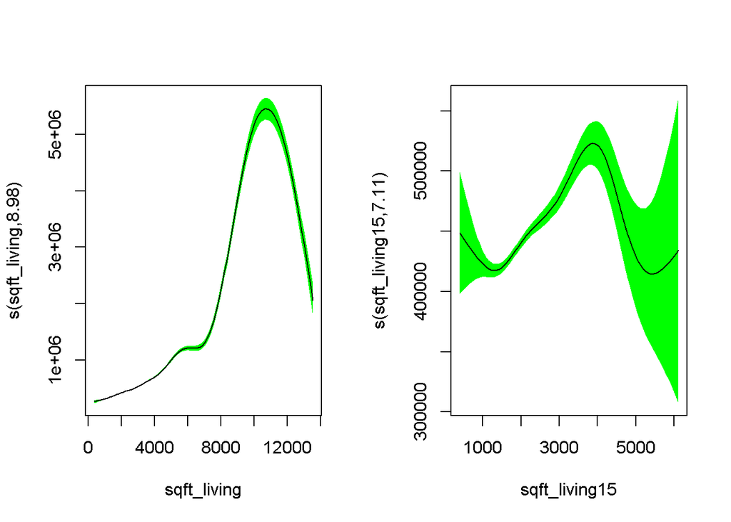

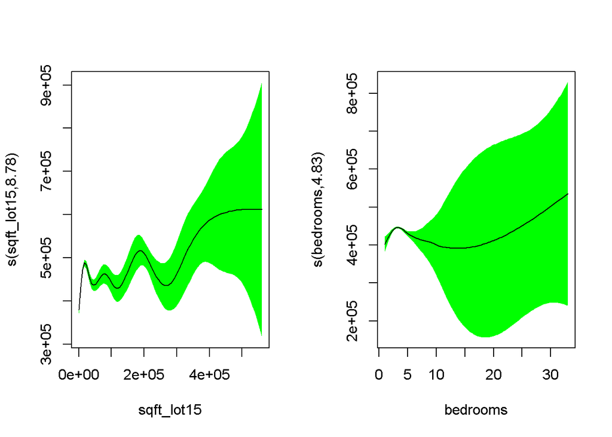

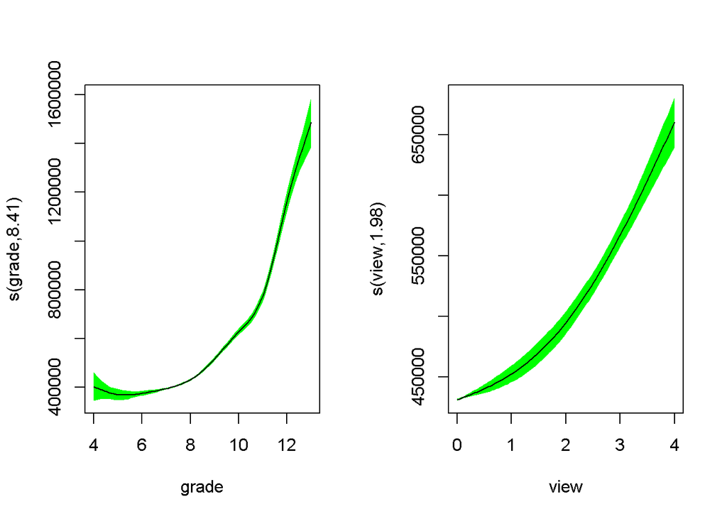

```r
layout(matrix(1:2, ncol = 2))
vis.gam (x=model_gam3,view=c("lat","long"),plot.type="persp")
plot(model_gam3, scale = 0,shade = TRUE, shade.col = "green", shift=coef(model_gam3)[1])
```

```r
#concurvity(model_gam,full=FALSE)
```

[figure not shown]

### GAM CHECK Resids vs linear pred

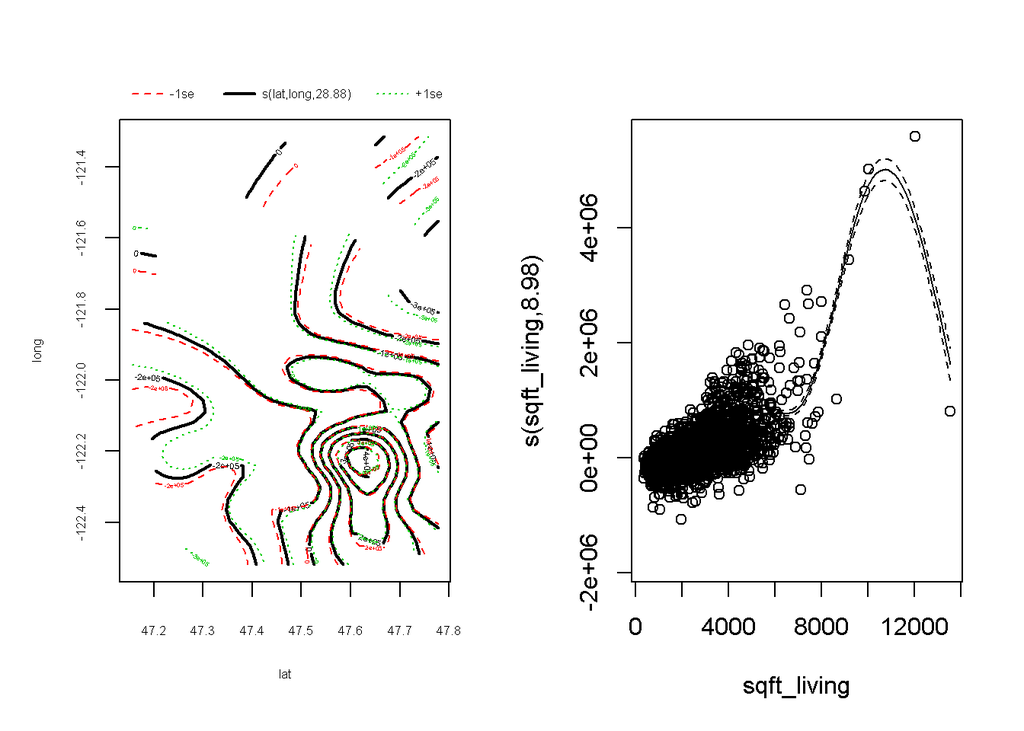

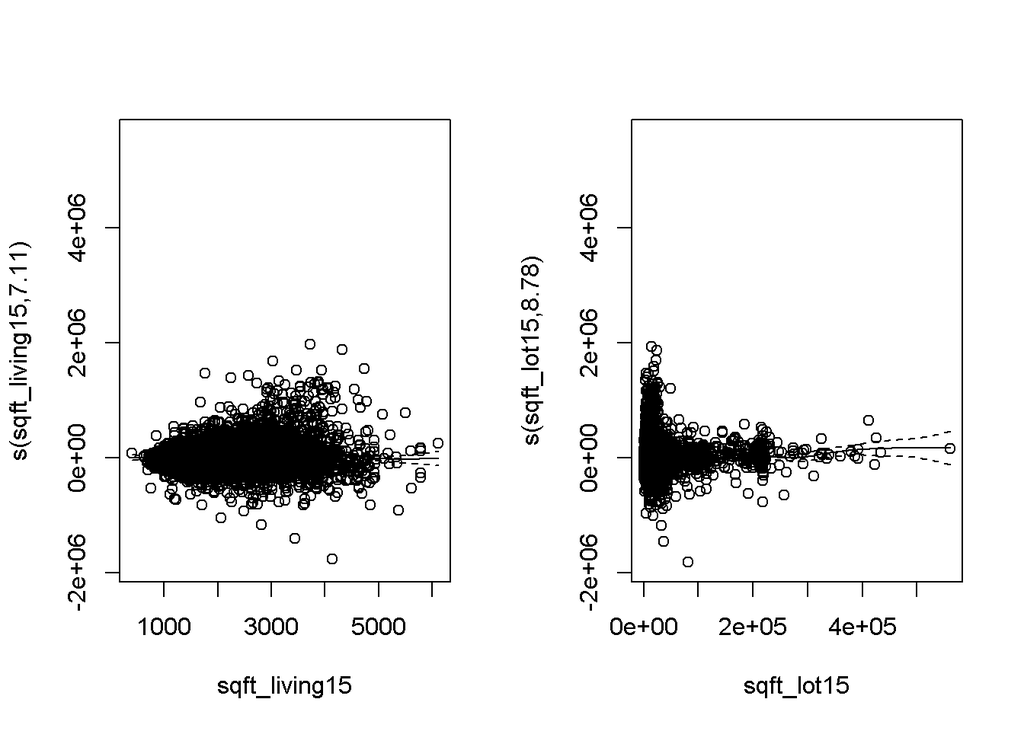

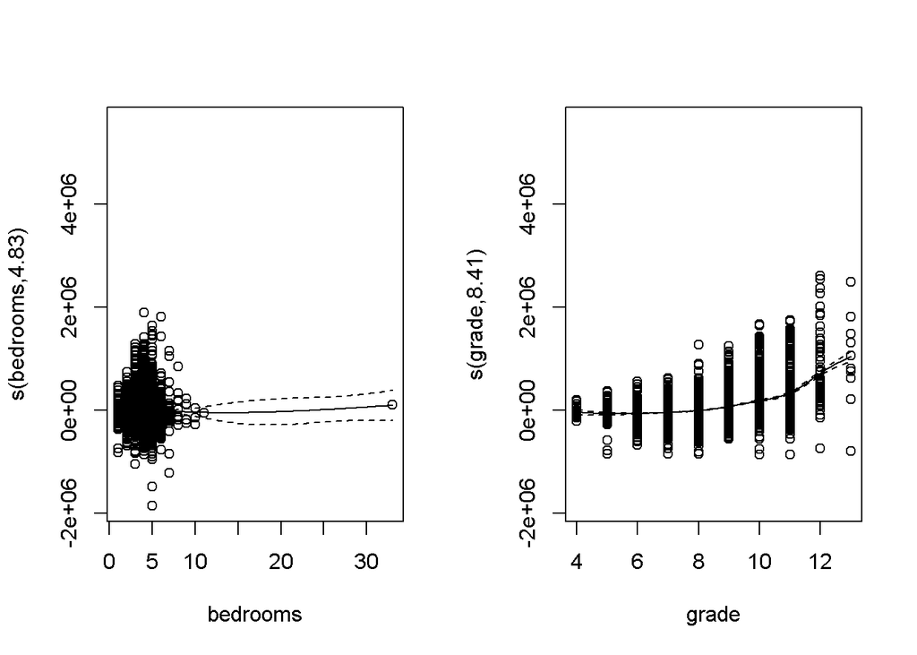

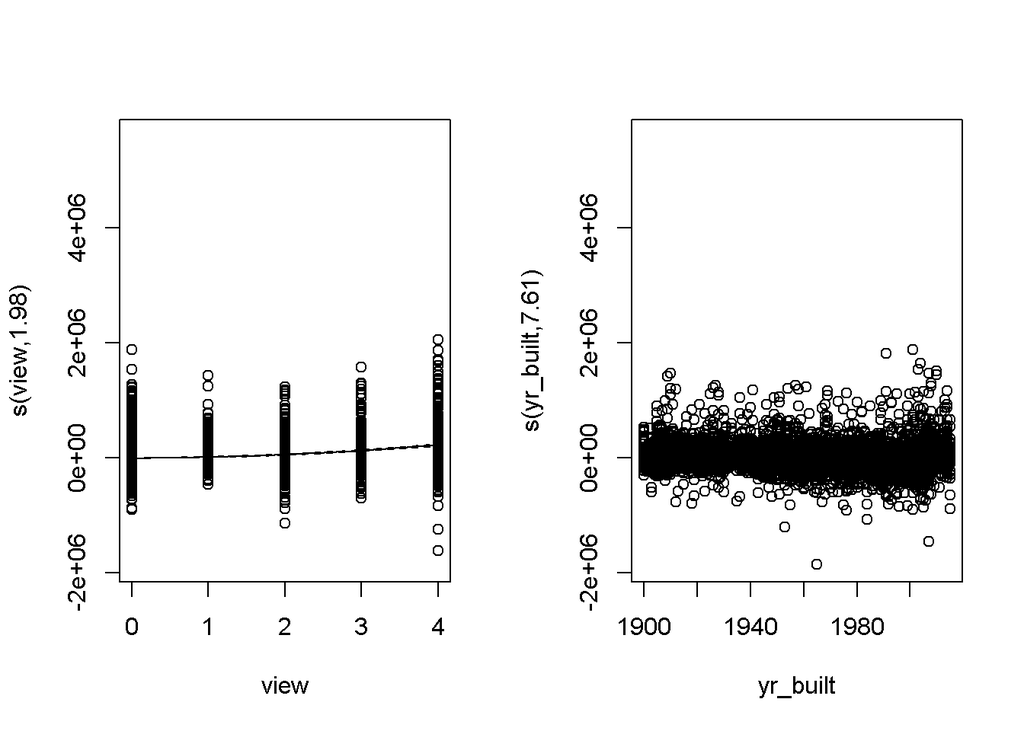

```r
par(mfrow = c(1, 2))
plot(model_gam3, residuals = TRUE, pch = 1)
```

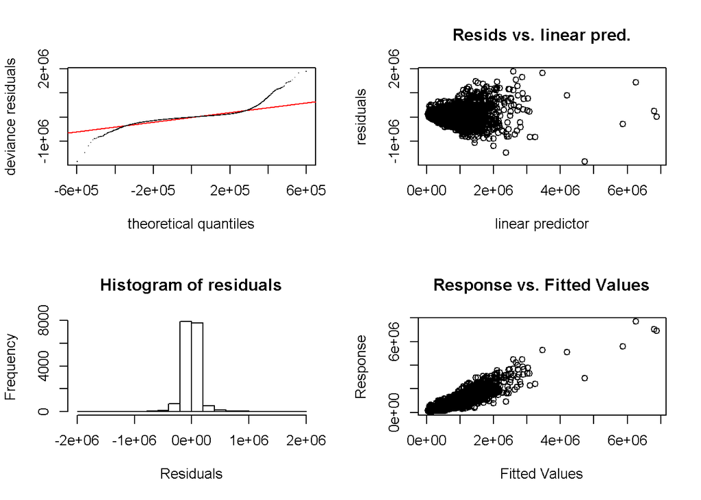

```
##
## Method: REML   Optimizer: outer newton
## full convergence after 12 iterations.
## Gradient range [-0.01058679,0.008060175]
## (score 230412.7 & scale 22173445068).
## Hessian positive definite, eigenvalue range [0.4795999,8634.04].
## Model rank =  88 / 88
##
## Basis dimension (k) checking results. Low p-value (k-index<1) may
## indicate that k is too low, especially if edf is close to k'.
##
##                     k'   edf k-index p-value
## s(lat,long)      29.00 28.88    0.69  <2e-16 ***
## s(sqft_living)    9.00  8.98    0.98    0.05 *
## s(sqft_living15)  9.00  7.11    0.98    0.14
## s(sqft_lot15)     9.00  8.78    0.98    0.10 .
## s(bedrooms)       9.00  4.83    1.02    0.90
## s(grade)          9.00  8.41    0.98    0.03 *
## s(view)           2.00  1.98    1.00    0.49
## s(yr_built)       9.00  7.61    1.00    0.38
## ---
## Signif. codes:  0 '***' 0.001 '**' 0.01 '*' 0.05 '.' 0.1 ' ' 1
```

```r
gam.check(model_gam3)
```